# STAT 420: Simulation Project

Alok K. Shukla

10/16/2016

This is the first Simulation Project Report for STAT420. It consists of three Simulation Studies; on Distributions, MSE of Estimators and RMSE for Prediction. The Data used in studies is provided externally in two csv files.

## Simulation Study 1, Distributions

### Introduction

\begin{equation} Y_i = \beta_0 + \beta_1 x_{i1} + \beta_2 x_{i2} + \beta_3 x_{i3} + \epsilon_i \end{equation}

where $\epsilon_i \sim N(0, \sigma^2)$ and

- $\beta_0 = 5$
- $\beta_1 = 1$
- $\beta_2 = 1$
- $\beta_3 = 1$

With a sample size $n=10$ and three levels of noise, $\sigma \in (1, 5, 10)$

Data is available in `study_1.csv` . We will be simulating 2500 times.

### Methods

#### Read Data

To populate the `study_1` data of predictors.

```r
study_1 <- read.csv("study_1.csv")
```

##### Initialization

Fixed parameters.

```r
beta_0 = 5
beta_1 = 1
beta_2 = 1
beta_3 = 1
n = 10
num_sims = 2500
x0 = rep(1,n)
x1 = study_1$x1
x2 = study_1$x2
x3 = study_1$x3
sigma = c(1,5,10)
beta_hat_2  = rep(0, num_sims)
s_e = rep(0, num_sims)
e_y = rep(0, num_sims)
x1_fix = -4
x2_fix = 2.5
x3_fix = 3
x_fix = c(1,x1_fix,x2_fix,x3_fix)
x0 = rep(1,nrow(study_1))
beta = c(beta_0,beta_1,beta_2,beta_3)
X = cbind(x0,study_1$x1,study_1$x2,study_1$x3)
C = solve(t(X) %*% X)
r = t(x_fix)%*%C%*%x_fix
```

#### Simulation function

A method for simulation so that it could be repeated for levels of noise.

```r
simulation1 = function(sigma){
  for(i in 1:num_sims) {
  eps         = rnorm(n, mean = 0 , sd = sigma)
  study_1$y   = beta_0 + beta_1 * x1 + beta_2 * x2 + beta_3 * x3 + eps
  fit         = lm(y ~ ., data = study_1)

  beta_hat_2[i]  = coef(fit)[3]
  y_hat = predict(fit,data=study_1)
  s_e[i] = summary(fit)$sigma#
  e_y[i] = coef(fit)[1]+coef(fit)[2]*x1_fix+coef(fit)[3]*x2_fix+coef(fit)[4]*x3_fix

  }
  cbind(beta_hat_2,s_e,e_y)
}
```

### Results

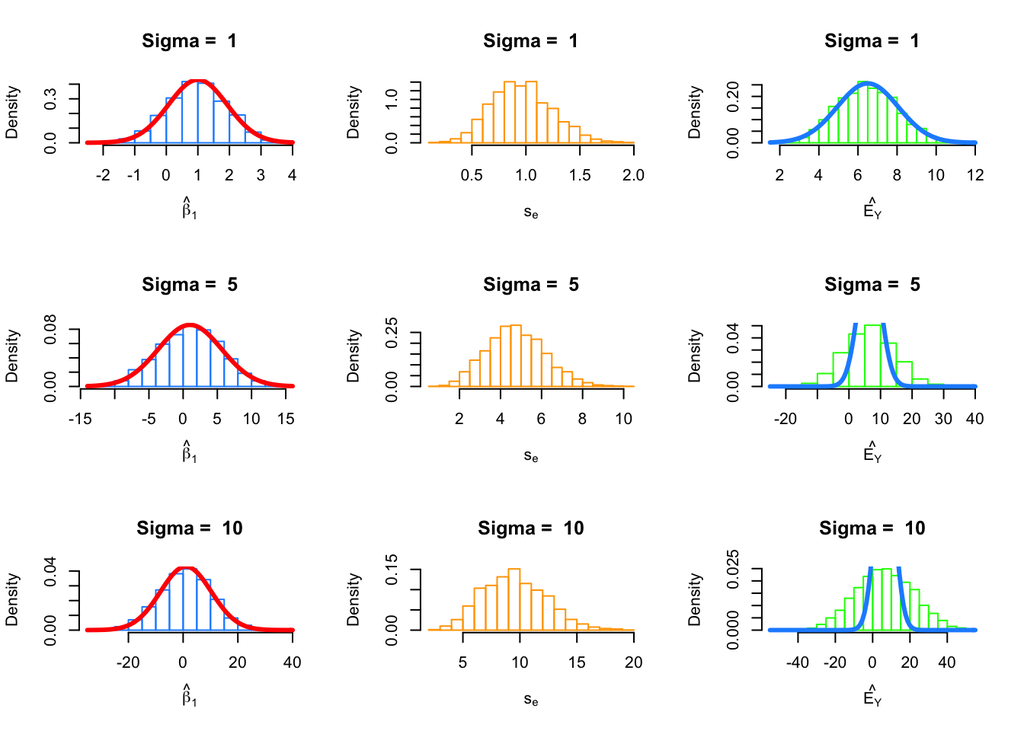

### Discussion

**Effect of Noise**

As noise increases, the spread of all distributions increases.

## Simulation Study 2, MSE of Estimators

### Introduction

In this study we simulate $MSE$, $Bias$ and $Var$ of one of the estimates, $\hat{\beta_1}$ using different sample sizes.

The MSE of an estimator can be decomposed into the bias and variance of the estimator.

\begin{equation} MSE(\hat{\beta}) = [Bias(\hat{\beta})] ^ 2 + Var[\hat{\beta}] \end{equation}

The bias of the estimator is given by

\begin{equation} Bias(\hat{\beta}) = E[\hat{\beta}] - \beta \end{equation}

We will simulate from the model

\begin{equation} Y_i = \beta_0 + \beta_1 x_{i1} + \beta_2 x_{i2} + \epsilon_i \end{equation}

where $\epsilon_i \sim N(0, \sigma^2)$ and

- $\beta_0 = 5$
- $\beta_1 = 2$
- $\beta_2 = 4$
- $\sigma = 4$

We will consider a sequence of increasing sample sizes.

- $n \in (10, 20, 30, 40, 50, 60, 70 , 80, 90, 100)$

We will be simulating the data 500 times for each sample size for each of following models.

- `y~x1`
- `y~x1+x2`
- `y~x1+x2+x3`

### Methods

#### Initialization

Fixed parameters.

```r
beta_0 = 5
beta_1 = 2
beta_2 = 4
sigma = 4
n = c(10, 20, 30, 40, 50, 60, 70 , 80, 90, 100)
num_sims = 500
beta_hat_1  = rep(0, num_sims)
temp_500 = rep(0, num_sims)
temp_3x500 = data.frame(temp_500,temp_500,temp_500)
beta_hat_1 = temp_3x500
bias_beta_hat_1 = c(0,0,0)
var_beta_hat_1 = c(0,0,0)
mse_beta_hat_1 = c(0,0,0)
```

#### Generate Simulation Data

This will create `study_2` data for simulation for different sample sizes.

```r
gen_sim_data = function(n = 100) {

  x1 = runif(n = n)
  x2 = runif(n = n)
  x3 = runif(n = n)
  y = beta_0 + beta_1 * x1 + beta_2 * x2 + rnorm(n = n, mean = 0, sd = sigma)

  data.frame(x1, x2, x3, y)

}
```

#### Simulation function

A method for simulation so that it could be repeated for different sample sizes.

```r
simulation2 = function(n){
  for(i in 1:num_sims) {
  study_2 = gen_sim_data(n)

  fit1           = lm(y ~ x1, data = study_2)
  fit2           = lm(y ~ x1+x2, data = study_2)
  fit3           = lm(y ~ x1+x2+x3, data = study_2)


  beta_hat_1[i,1] = coef(fit1)[2]
  beta_hat_1[i,2] = coef(fit2)[2]
  beta_hat_1[i,3] = coef(fit3)[2]
  }

  for(i in 1:3){
    bias_beta_hat_1[i] = mean(beta_hat_1[,i])-beta_1
    var_beta_hat_1[i] = var(beta_hat_1[,i])
    mse_beta_hat_1[i] = (bias_beta_hat_1[i]^2)+var_beta_hat_1[i]
  }

  cbind(mse_beta_hat_1, bias_beta_hat_1, var_beta_hat_1)
}
```

### Results

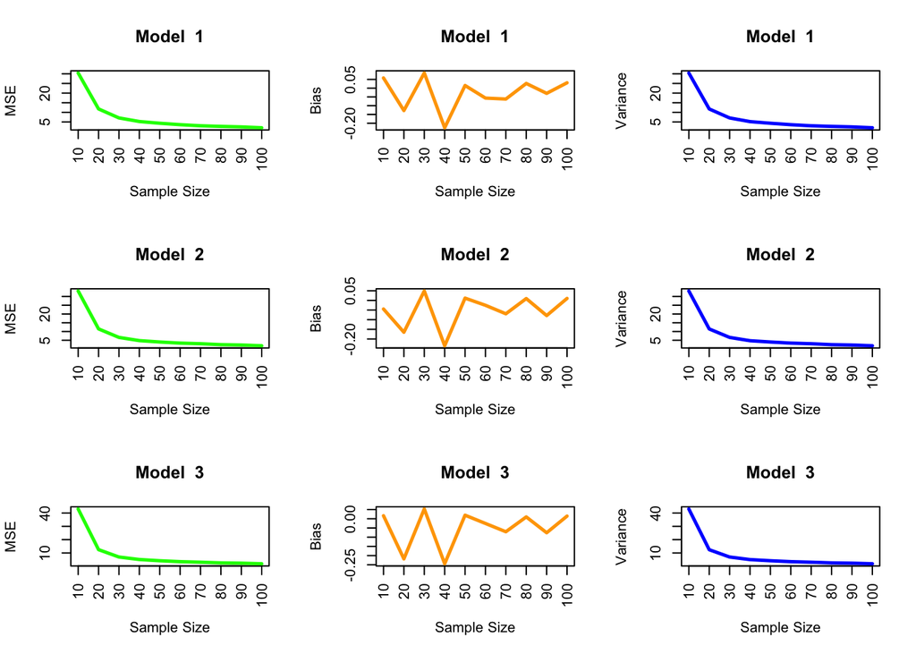

### Discussion

**Effect of Sample Size**

MSE and Variance, both decrease with increased sample size; and the Bias fluctuates and tends towards zero.

**Correct vs Incorrect fit**

It doesn’t matter if we fit correct form or the incorrect form; the estimators are estimated correctly according to present predictors.

## Simulation Study 3, RMSE for Prediction

### Introduction

In this Simulation Study we will see how effective is using RMSE as a parameter for selecting the best model. We will be simulating following model \begin{equation} Y_i = \beta_0 + \beta_1 x_{i1} + \beta_2 x_{i2} + \beta_3 x_{i3} + \beta_4 x_{i4} + \epsilon_i \end{equation}

where $\epsilon_i \sim N(0, \sigma^2)$ and

We will consider a sample size of 400, and three possible levels of noise. That is three values of $\sigma$.

- $n=400$
- $\sigma \in (1, 5, 10)$

Data is available in `study_3.csv`. Each time we simulate data, there is a random split for training and test data (200 rows rach) and fit each of following model

- y ~ x1
- y ~ x1+x2
- y ~ x1+x2+x3
- y ~ x1+x2+x3+x4 . .
- y ~ x1 + x2 + x3 + x4 + x5 + x6 + x7 + x8 + x9

Each time we calculate train and test RMSE and repeat this process for each of three levels of $\sigma$ .

### Methods

#### Read Data

To populate the `study_3` data of predixtors and prepare tarin and test data.

```r
study_3 <- read.csv("study_3.csv")
```

#### Initialization

Fixed parameters.

```r
beta_0 = 0
beta_1 = 4
beta_2 = 3
beta_3 = 2
beta_4 = 1
sigma = c(1,5,10)
n = 200
num_sims = 500
train_error <- data.frame(matrix(ncol = 9, nrow = 2))
rownames(train_error) = c("Train","Test")
colnames(train_error) = c("1","2","3","4","5","6","7","8","9")
test_error  <- data.frame(matrix(ncol = 9, nrow = 2))
rownames(test_error) = rownames(train_error)
colnames(test_error) = colnames(train_error)
results = rbind(train_error,test_error)
chosen_model = rep(0,num_sims)
```

#### Simulation function

A method for simulation so that it could be repeated for levels of noise.

```r
simulation3 = function(sigma){
  for(i in 1:num_sims) {
  train_index = sample(1:nrow(study_3), 200)
  train_data  = study_3[train_index, ]
  test_data = study_3[-train_index, ]
  eps = rnorm(n, mean = 0 , sd = sigma)
  train_data$y= beta_0 + beta_1 * train_data$x1 + beta_2 *train_data$x2 + beta_3 *train_data$x3 + beta_4*train_data$x4 + eps
  fit1 = lm(y ~ x1, data = train_data)
  fit2 = lm(y ~ x1 + x2, data = train_data)
  fit3 = lm(y ~ x1 + x2 + x3, data = train_data)
  fit4 = lm(y ~ x1 + x2 + x3 + x4, data = train_data)
  fit5 = lm(y ~ x1 + x2 + x3 + x4 + x5, data = train_data)
  fit6 = lm(y ~ x1 + x2 + x3 + x4 + x5 + x6, data = train_data)
  fit7 = lm(y ~ x1 + x2 + x3 + x4 + x5 + x6 + x7, data = train_data)
  fit8 = lm(y ~ x1 + x2 + x3 + x4 + x5 + x6 + x7 + x8, data = train_data)
  fit9 = lm(y ~ x1 + x2 + x3 + x4 + x5 + x6 + x7 + x8 + x9, data = train_data)

  # calculate all train errors
  train_error[i,] = c(
  rmse(train_data$y, predict(fit1, train_data)),
  rmse(train_data$y, predict(fit2, train_data)),
  rmse(train_data$y, predict(fit3, train_data)),
  rmse(train_data$y, predict(fit4, train_data)),
  rmse(train_data$y, predict(fit5, train_data)),
  rmse(train_data$y, predict(fit6, train_data)),
  rmse(train_data$y, predict(fit7, train_data)),
  rmse(train_data$y, predict(fit8, train_data)),
  rmse(train_data$y, predict(fit9, train_data))
  )

  # calculate all test errors
  test_error[i,] = c(
  rmse(test_data$y, predict(fit1, test_data)),
  rmse(test_data$y, predict(fit2, test_data)),
  rmse(test_data$y, predict(fit3, test_data)),
  rmse(test_data$y, predict(fit4, test_data)),
  rmse(test_data$y, predict(fit5, test_data)),
  rmse(test_data$y, predict(fit6, test_data)),
  rmse(test_data$y, predict(fit7, test_data)),
  rmse(test_data$y, predict(fit8, test_data)),
  rmse(test_data$y, predict(fit9, test_data))
  )

  (chosen_model[i] = which.min(test_error[i,]))
  #message(paste("Chosen model is ",chosen_model[i]))


  }
  message(paste("Overall chosen model is ",Mode(chosen_model)))
  rbind(colMeans(train_error),colMeans(test_error))
}

# function to evaluate rmse
rmse  = function(actual, predicted) {
  sqrt(mean((actual - predicted) ^ 2))
}

Mode = function(x) {
  ux = unique(x)
  ux[which.max(tabulate(match(x, ux)))]
}
```

### Results

```
## Overall chosen model is  1
## Overall chosen model is  1
## Overall chosen model is  1
```

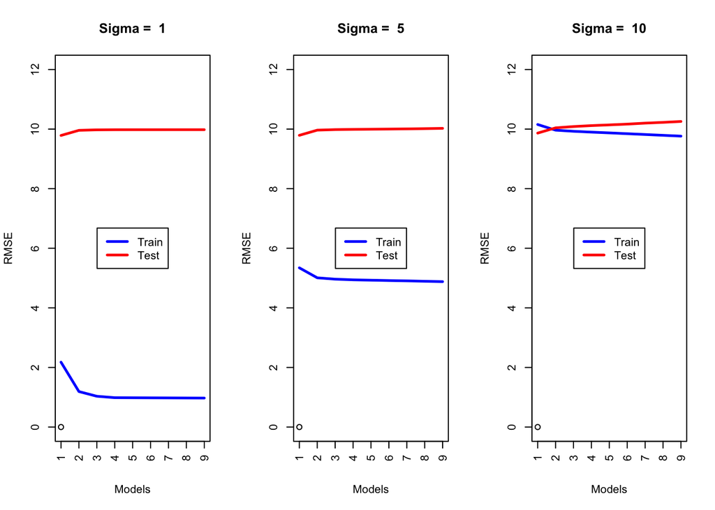

### Discussion

**Effect of Noise**

As noise increases, train RMSE increases while test RMSE remains almost the same.

**Model Selection**